# Getting started

```python
import numpy as np
import pandas as pd
pd.options.mode.chained_assignment = None
import matplotlib.pyplot as plt
from  matplotlib.ticker import FuncFormatter
import seaborn as sns
```

```python
df = pd.read_csv("C:\\Users\\vikra\\Downloads\\Netflix2\\netflix_titles.csv")
```

```python
df.head(10)
```

|  | show_id | type | title | director | cast | country | date_added | release_year | rating | duration | listed_in | description |
| --- | --- | --- | --- | --- | --- | --- | --- | --- | --- | --- | --- | --- |
| 0 | 81145628 | Movie | Norm of the North: King Sized Adventure | Richard Finn, Tim Maltby | Alan Marriott, Andrew Toth, Brian Dobson, Cole... | United States, India, South Korea, China | September 9, 2019 | 2019 | TV-PG | 90 min | Children & Family Movies, Comedies | Before planning an awesome wedding for his gra... |
| 1 | 80117401 | Movie | Jandino: Whatever it Takes | NaN | Jandino Asporaat | United Kingdom | September 9, 2016 | 2016 | TV-MA | 94 min | Stand-Up Comedy | Jandino Asporaat riffs on the challenges of ra... |
| 2 | 70234439 | TV Show | Transformers Prime | NaN | Peter Cullen, Sumalee Montano, Frank Welker, J... | United States | September 8, 2018 | 2013 | TV-Y7-FV | 1 Season | Kids' TV | With the help of three human allies, the Autob... |
| 3 | 80058654 | TV Show | Transformers: Robots in Disguise | NaN | Will Friedle, Darren Criss, Constance Zimmer, ... | United States | September 8, 2018 | 2016 | TV-Y7 | 1 Season | Kids' TV | When a prison ship crash unleashes hundreds of... |
| 4 | 80125979 | Movie | #realityhigh | Fernando Lebrija | Nesta Cooper, Kate Walsh, John Michael Higgins... | United States | September 8, 2017 | 2017 | TV-14 | 99 min | Comedies | When nerdy high schooler Dani finally attracts... |
| 5 | 80163890 | TV Show | Apaches | NaN | Alberto Ammann, Eloy Azorín, Verónica Echegui,... | Spain | September 8, 2017 | 2016 | TV-MA | 1 Season | Crime TV Shows, International TV Shows, Spanis... | A young journalist is forced into a life of cr... |
| 6 | 70304989 | Movie | Automata | Gabe Ibáñez | Antonio Banderas, Dylan McDermott, Melanie Gri... | Bulgaria, United States, Spain, Canada | September 8, 2017 | 2014 | R | 110 min | International Movies, Sci-Fi & Fantasy, Thrillers | In a dystopian future, an insurance adjuster f... |
| 7 | 80164077 | Movie | Fabrizio Copano: Solo pienso en mi | Rodrigo Toro, Francisco Schultz | Fabrizio Copano | Chile | September 8, 2017 | 2017 | TV-MA | 60 min | Stand-Up Comedy | Fabrizio Copano takes audience participation t... |
| 8 | 80117902 | TV Show | Fire Chasers | NaN | NaN | United States | September 8, 2017 | 2017 | TV-MA | 1 Season | Docuseries, Science & Nature TV | As California's 2016 fire season rages, brave ... |
| 9 | 70304990 | Movie | Good People | Henrik Ruben Genz | James Franco, Kate Hudson, Tom Wilkinson, Omar... | United States, United Kingdom, Denmark, Sweden | September 8, 2017 | 2014 | R | 90 min | Action & Adventure, Thrillers | A struggling couple can't believe their luck w... |

```python
df.shape
```

```
(6234, 12)
```

Let's take a look at the datatype of each column

```python
df.dtypes
```

```
show_id          int64
type            object
title           object
director        object
cast            object
country         object
date_added      object
release_year     int64
rating          object
duration        object
listed_in       object
description     object
dtype: object
```

Check for NA's in each column

```python
df.isnull().sum()
```

```
show_id            0
type               0
title              0
director        1969
cast             570
country          476
date_added        11
release_year       0
rating            10
duration           0
listed_in          0
description        0
dtype: int64
```

```python
df.rating[df['rating']=='UR'].value_counts()
```

```
UR    7
Name: rating, dtype: int64
```

We have 10 instances where the rating of a show or movie is missing. We will include these instances as 'Unrated' (UR).

This will take the total of UR rating to 17.

```python
df['rating'] = df['rating'].fillna('UR')
```

We will now divide the dataset into two groups: one containing movies on Netflix and the other containing only the TV shows.

We will then clean the subsets one by one.

```python
movies_df = df[df['type'] == 'Movie']
tv_df = df[df['type'] == 'TV Show']
```

# Working with the Movies subset

```python
movies_df.shape
```

```
(4265, 12)
```

Checking for the NA values

```python
movies_df.isna().sum()
```

```
show_id           0
type              0
title             0
director        128
cast            360
country         195
date_added        1
release_year      0
rating            0
duration          0
listed_in         0
description       0
dtype: int64
```

We will fill the NA values in the 'country' column with 'Undefined'.

We will also fill the empty instances in 'date_added' column with the year as 2020.

```python
movies_df['country'] = movies_df['country'].fillna('Undefined')
```

```python
movies_df['date_added'] = movies_df['date_added'].fillna('January 1, 2020')
```

Adding two more columns to the movies subset: one containing the month the content was added and other containing the year it was added in

```python
movies_df['month_added'] = pd.to_datetime(movies_df['date_added']).dt.month_name()
movies_df['year_added'] = pd.to_datetime(movies_df['date_added']).dt.year
```

```python
movies_df.head(10)
```

|  | show_id | type | title | director | cast | country | date_added | release_year | rating | duration | listed_in | description | month_added | year_added |
| --- | --- | --- | --- | --- | --- | --- | --- | --- | --- | --- | --- | --- | --- | --- |
| 0 | 81145628 | Movie | Norm of the North: King Sized Adventure | Richard Finn, Tim Maltby | Alan Marriott, Andrew Toth, Brian Dobson, Cole... | United States, India, South Korea, China | September 9, 2019 | 2019 | TV-PG | 90 min | Children & Family Movies, Comedies | Before planning an awesome wedding for his gra... | September | 2019 |
| 1 | 80117401 | Movie | Jandino: Whatever it Takes | NaN | Jandino Asporaat | United Kingdom | September 9, 2016 | 2016 | TV-MA | 94 min | Stand-Up Comedy | Jandino Asporaat riffs on the challenges of ra... | September | 2016 |
| 4 | 80125979 | Movie | #realityhigh | Fernando Lebrija | Nesta Cooper, Kate Walsh, John Michael Higgins... | United States | September 8, 2017 | 2017 | TV-14 | 99 min | Comedies | When nerdy high schooler Dani finally attracts... | September | 2017 |
| 6 | 70304989 | Movie | Automata | Gabe Ibáñez | Antonio Banderas, Dylan McDermott, Melanie Gri... | Bulgaria, United States, Spain, Canada | September 8, 2017 | 2014 | R | 110 min | International Movies, Sci-Fi & Fantasy, Thrillers | In a dystopian future, an insurance adjuster f... | September | 2017 |
| 7 | 80164077 | Movie | Fabrizio Copano: Solo pienso en mi | Rodrigo Toro, Francisco Schultz | Fabrizio Copano | Chile | September 8, 2017 | 2017 | TV-MA | 60 min | Stand-Up Comedy | Fabrizio Copano takes audience participation t... | September | 2017 |
| 9 | 70304990 | Movie | Good People | Henrik Ruben Genz | James Franco, Kate Hudson, Tom Wilkinson, Omar... | United States, United Kingdom, Denmark, Sweden | September 8, 2017 | 2014 | R | 90 min | Action & Adventure, Thrillers | A struggling couple can't believe their luck w... | September | 2017 |
| 10 | 80169755 | Movie | Joaquín Reyes: Una y no más | José Miguel Contreras | Joaquín Reyes | Undefined | September 8, 2017 | 2017 | TV-MA | 78 min | Stand-Up Comedy | Comedian and celebrity impersonator Joaquín Re... | September | 2017 |
| 11 | 70299204 | Movie | Kidnapping Mr. Heineken | Daniel Alfredson | Jim Sturgess, Sam Worthington, Ryan Kwanten, A... | Netherlands, Belgium, United Kingdom, United S... | September 8, 2017 | 2015 | R | 95 min | Action & Adventure, Dramas, International Movies | When beer magnate Alfred "Freddy" Heineken is ... | September | 2017 |
| 12 | 80182480 | Movie | Krish Trish and Baltiboy | NaN | Damandeep Singh Baggan, Smita Malhotra, Baba S... | Undefined | September 8, 2017 | 2009 | TV-Y7 | 58 min | Children & Family Movies | A team of minstrels, including a monkey, cat a... | September | 2017 |
| 13 | 80182483 | Movie | Krish Trish and Baltiboy: Battle of Wits | Munjal Shroff, Tilak Shetty | Damandeep Singh Baggan, Smita Malhotra, Baba S... | Undefined | September 8, 2017 | 2013 | TV-Y7 | 62 min | Children & Family Movies | An artisan is cheated of his payment, a lion o... | September | 2017 |

In order to visualize the country and genres of the movies, we first need to clean the columns and bring them in an uniform format.

By taking a closer look at the dataset we see that the comma spacing in some instances is different than others.

```python
movies_df['country'] = movies_df.country.str.replace(", | ,", ",")
movies_df['listed_in'] = movies_df.listed_in.str.replace(", | ,", ",")
```

Now once we have the column in an uniform format, we split the column and create a new dataframe containg the show_id and the country names where a movie was released

```python
movies_country_df = pd.DataFrame(movies_df.country.str.split(',').tolist(), index=movies_df.show_id).stack()
movies_country_df = movies_country_df.reset_index([0, 'show_id'])
movies_country_df.columns = ['show_id', 'country']
```

# Which are the countries where most number of movies are available?

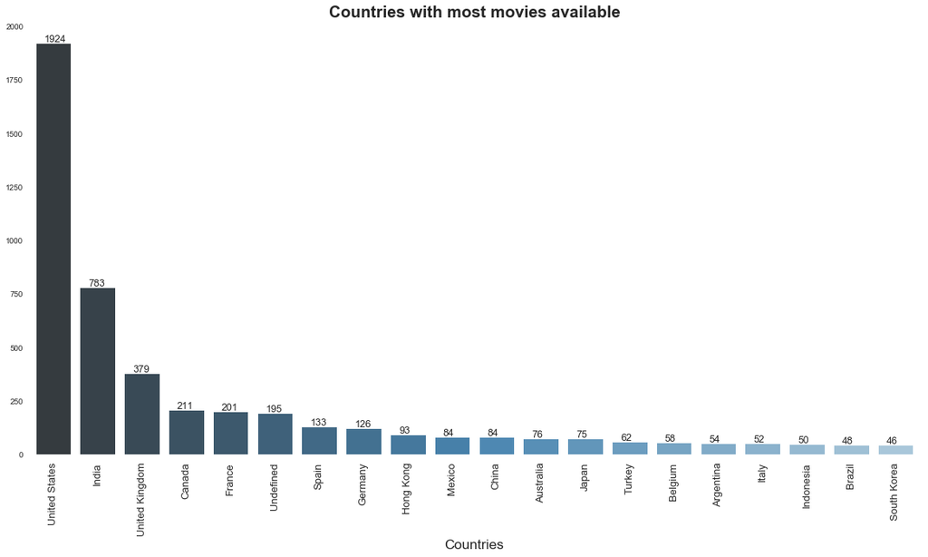

```python
plt.figure(figsize=(20,10))
sns.set(style="white")

ax = sns.countplot(x="country", data=movies_country_df, palette='Blues_d', order = movies_country_df.country.value_counts().iloc[:20].index)

ax.grid(False)
ax.set_xticklabels(ax.get_xticklabels(),rotation = 90, fontsize = 13)
ax.set_yticklabels(ax.get_yticks(), size = 10)
sns.despine(bottom = True, left = True)
plt.title('Countries with most movies available', fontsize = 20.5, fontweight = 'bold')
plt.xlabel('Countries', fontsize = 17.5)
plt.ylabel('')
plt.gca().yaxis.set_major_formatter(FuncFormatter(lambda x, _: int(x)))

for p in ax.patches:
        ax.annotate('{:}'.format(p.get_height()),(p.get_x()+0.2, p.get_height()+5), fontsize = 12.5)
```

We can see that United States has the most number of movies available on Netflix. India comes a distant second with less than half the movies available than in the US.

```python
movies_genre_df = pd.DataFrame(movies_df.listed_in.str.split(',').tolist(), index=movies_df.show_id).stack()
movies_genre_df = movies_genre_df.reset_index([0, 'show_id'])
movies_genre_df.columns = ['show_id', 'genre']
```

# Which movie genres are the most frequent on Netflix?

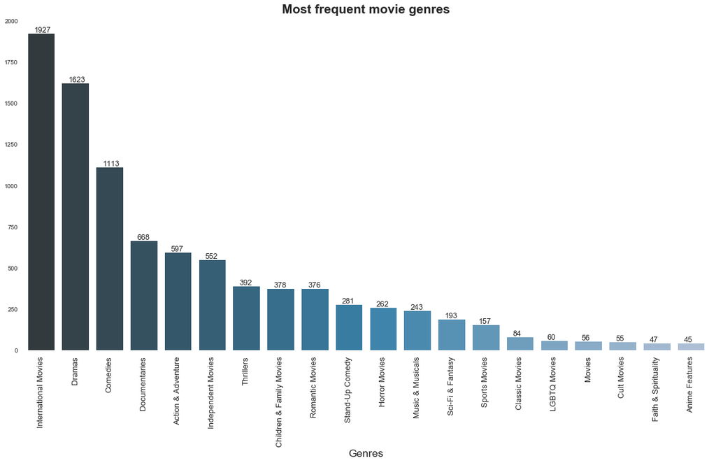

```python
plt.figure(figsize=(20,10))
sns.set(style="white")

ax = sns.countplot(x="genre", data=movies_genre_df, palette="PuBu_d", order = movies_genre_df.genre.value_counts().iloc[:20].index)

ax.grid(False)
ax.set_xticklabels(ax.get_xticklabels(),rotation = 90, fontsize = 13)
ax.set_yticklabels(ax.get_yticks(), size = 10)
sns.despine(bottom = True, left = True)
plt.title('Most frequent movie genres', fontsize = 20.5, fontweight = 'bold')
plt.xlabel('Genres', fontsize = 17.5)
plt.ylabel('')
plt.gca().yaxis.set_major_formatter(FuncFormatter(lambda x, _: int(x)))

for p in ax.patches:
        ax.annotate('{:}'.format(p.get_height()),(p.get_x()+0.2, p.get_height()+5), fontsize = 12.5)
```

# Which year saw the most number of movies getting added on Netflix?

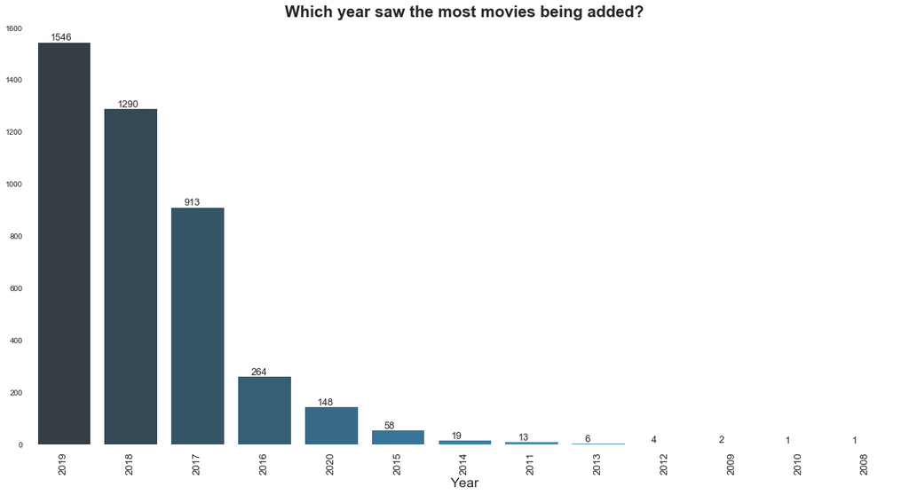

```python
plt.figure(figsize=(20,10))
sns.set(style="white")

ax = sns.countplot(x="year_added", data=movies_df, palette='PuBu_d', order = movies_df.year_added.value_counts().index)

ax.grid(False)
ax.set_xticklabels(ax.get_xticklabels(),rotation = 90, fontsize = 13)
ax.set_yticklabels(ax.get_yticks(), size = 10)
sns.despine(bottom = True, left = True)
plt.title('Which year saw the most movies being added?', fontsize = 20.5, fontweight = 'bold')
plt.xlabel('Year', fontsize = 17.5)
plt.ylabel('')
plt.gca().yaxis.set_major_formatter(FuncFormatter(lambda x, _: int(x)))

for p in ax.patches:
        ax.annotate('{:}'.format(p.get_height()),(p.get_x()+0.2, p.get_height()+5), fontsize = 12.5)
```

# Which months saw the most number of movies getting added on Netflix? (All years inclusive)

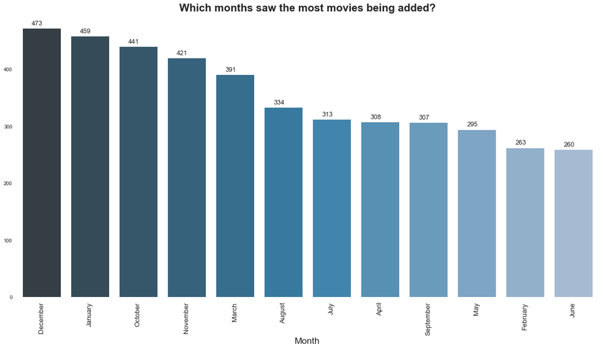

```python
plt.figure(figsize=(20,10))
sns.set(style="white")

ax = sns.countplot(x="month_added", data=movies_df, palette='PuBu_d', order = movies_df.month_added.value_counts().index)

ax.grid(False)
ax.set_xticklabels(ax.get_xticklabels(),rotation = 90, fontsize = 13)
ax.set_yticklabels(ax.get_yticks(), size = 10)
sns.despine(bottom = True, left = True)
plt.title('Which months saw the most movies being added?', fontsize = 20.5, fontweight = 'bold')
plt.xlabel('Month', fontsize = 17.5)
plt.ylabel('')
plt.gca().yaxis.set_major_formatter(FuncFormatter(lambda x, _: int(x)))

for p in ax.patches:
        ax.annotate('{:}'.format(p.get_height()),(p.get_x()+0.2, p.get_height()+5), fontsize = 12.5)
```

# Heatmap to drill down into the month-year relationship

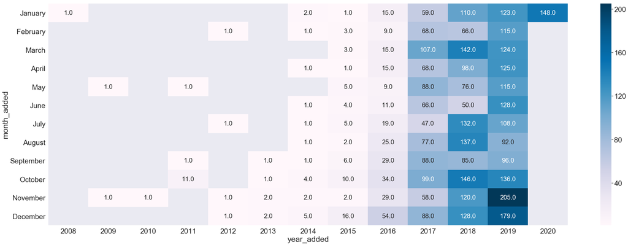

```python
plt.figure(figsize=(20,10))

movies_heatmap_df = movies_df.groupby(['year_added', 'month_added']).size().reset_index(name='count')

month_ordered = [ 'January', 'February', 'March', 'April', 'May', 'June', 'July', 'August','September','October','November','December']

movies_heatmap_df['month_added'] = movies_heatmap_df['month_added'].astype(pd.api.types.CategoricalDtype(month_ordered))

plt.figure(figsize=(40,14))
sns.set(font_scale=2.25)

ax = pd.pivot_table(movies_heatmap_df, values= 'count', index=['month_added'], columns='year_added')
sns.heatmap(ax, cmap="PuBu", annot = True, fmt = ".1f", annot_kws={'size':22})
```

# A genrewise look at how the movies got added over the years

```python
movies_genrewise_df = movies_df[['show_id', 'year_added']]
movies_genrewise_df = pd.merge(movies_genre_df, movies_genrewise_df, on='show_id')
```

```python
movies_genrewise_df = movies_genrewise_df.groupby(['year_added', 'genre']).size().reset_index(name='count')
```

```python
genre_list = ['International Movies','Dramas','Comedies','Documentaries','Action & Adventure', 'Independent Movies', 'Thrillers','Children & Family Movies', 'Romantic Movies', 'Stand-Up Comedy' ]
movies_genrewise_df = movies_genrewise_df[movies_genrewise_df['genre'].isin(genre_list)]
```

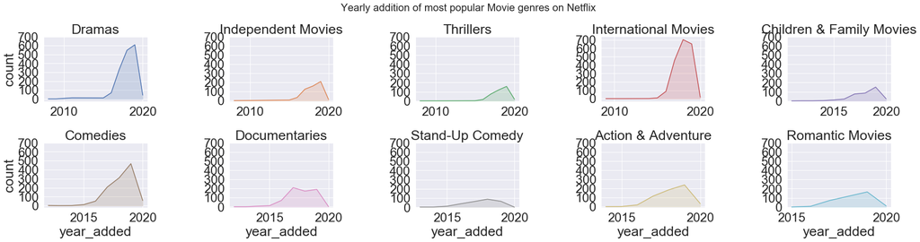

```python
g = sns.FacetGrid(movies_genrewise_df, col= 'genre', hue='genre', col_wrap=5, height = 3.5, aspect = 1.5, sharex=False, sharey = False)
g = g.map(plt.plot, 'year_added', 'count')
g = g.map(plt.fill_between, 'year_added', 'count', alpha=0.2)
g = g.set_titles("{col_name}")
g = g.set(yticks = np.arange(0,800,100))


plt.subplots_adjust(top=0.85)
g.fig.suptitle('Yearly addition of most popular Movie genres on Netflix', fontsize = 20.5)
```

'Dramas', 'Independent Movies' and 'Thrillers' have their been on Netflix since 2008 while genres like 'Romantics Movies', 'Stand-Up Comedy' and 'Action & Adventure' appear to be fairly new additions on Netflix.

# Duration between a movie's release and its addition on Netflix

```python
movies_df['duration'] = movies_df['year_added'] - movies_df['release_year']
```

```python
duration_df = pd.Series(pd.cut(movies_df['duration'], np.arange(0,80,5)).value_counts()).reset_index()
```

```python
duration_df = duration_df.rename(columns= {'index': 'bins', 'duration':'counts'})
```

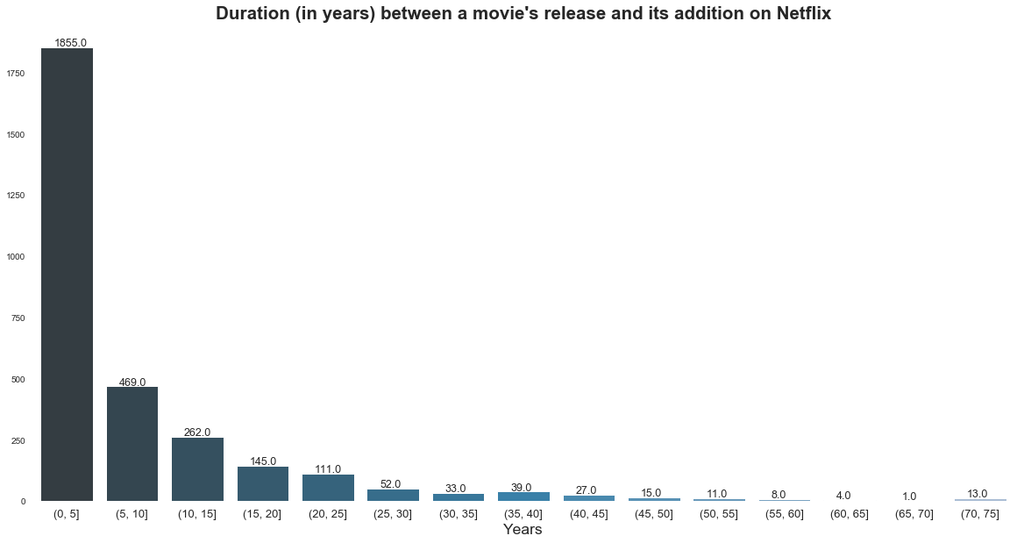

```python
plt.figure(figsize=(20,10))
sns.set(style="white")

ax = sns.barplot(x = duration_df['bins'], y = duration_df['counts'] ,data=duration_df, palette='PuBu_d')

ax.grid(False)
ax.set_xticklabels(ax.get_xticklabels(),fontsize = 13)
ax.set_yticklabels(ax.get_yticks(), size = 10)
sns.despine(bottom = True, left = True)
plt.title("Duration (in years) between a movie's release and its addition on Netflix", fontsize = 20.5, fontweight = 'bold')
plt.xlabel('Years', fontsize = 17.5)
plt.ylabel('')
plt.gca().yaxis.set_major_formatter(FuncFormatter(lambda x, _: int(x)))

for p in ax.patches:
        ax.annotate('{:}'.format(p.get_height()),(p.get_x()+0.2, p.get_height()+5), fontsize = 12.5)
```

We observe an interesting fact about 13 movies being 70 to 75 years old when they were added on Netflix.

Let's take a look at those 13 movies

# Oldest movies on Netflix

```python
movies_df[movies_df.release_year.isin(movies_df['release_year'].nsmallest(13))]
```

|  | show_id | type | title | director | cast | country | date_added | release_year | rating | duration | listed_in | description | month_added | year_added |
| --- | --- | --- | --- | --- | --- | --- | --- | --- | --- | --- | --- | --- | --- | --- |
| 2005 | 80119190 | Movie | Know Your Enemy - Japan | Frank Capra, Joris Ivens | Walter Huston, Dana Andrews | United States | March 31, 2017 | 1945 | TV-14 | 72 | Classic Movies,Documentaries | Though culturally insensitive by modern standa... | March | 2017 |
| 2006 | 80119187 | Movie | Let There Be Light | John Huston | Walter Huston | United States | March 31, 2017 | 1946 | TV-PG | 71 | Classic Movies,Documentaries | Some returning combat veterans suffer scars th... | March | 2017 |
| 2009 | 80119192 | Movie | Nazi Concentration Camps | George Stevens | NaN | United States | March 31, 2017 | 1945 | TV-MA | 72 | Classic Movies,Documentaries | Shocking footage shows Nazi concentration camp... | March | 2017 |
| 2011 | 60027945 | Movie | Prelude to War | Frank Capra | NaN | United States | March 31, 2017 | 1942 | TV-PG | 75 | Classic Movies,Documentaries | Frank Capra's documentary chronicles the rise ... | March | 2017 |
| 2012 | 80119188 | Movie | San Pietro | John Huston | NaN | United States | March 31, 2017 | 1945 | TV-14 | 72 | Classic Movies,Documentaries | After the Allies invade Italy, the Liri Valley... | March | 2017 |
| 2013 | 60027942 | Movie | The Battle of Midway | John Ford | Henry Fonda, Jane Darwell | United States | March 31, 2017 | 1942 | TV-G | 75 | Classic Movies,Documentaries | Director John Ford captures combat footage of ... | March | 2017 |
| 2017 | 80119194 | Movie | The Memphis Belle: A Story of a\nFlying Fortress | William Wyler | NaN | United States | March 31, 2017 | 1944 | TV-PG | 73 | Classic Movies,Documentaries | This documentary centers on the crew of the B-... | March | 2017 |
| 2019 | 80119191 | Movie | The Negro Soldier | Stuart Heisler | NaN | United States | March 31, 2017 | 1944 | TV-14 | 73 | Classic Movies,Documentaries | This documentary urged African Americans to en... | March | 2017 |
| 2021 | 80119189 | Movie | Tunisian Victory | Frank Capra, John Huston, Hugh Stewart, Roy Bo... | Burgess Meredith | United States,United Kingdom | March 31, 2017 | 1944 | TV-PG | 73 | Classic Movies,Documentaries | British and American troops join forces to lib... | March | 2017 |
| 2022 | 80119186 | Movie | Undercover: How to Operate Behind Enemy Lines | John Ford | NaN | United States | March 31, 2017 | 1943 | TV-PG | 74 | Classic Movies,Documentaries | This World War II-era training film dramatizes... | March | 2017 |
| 2023 | 70013050 | Movie | Why We Fight: The Battle of Russia | Frank Capra, Anatole Litvak | NaN | United States | March 31, 2017 | 1943 | TV-14 | 74 | Documentaries | This installment of Frank Capra's acclaimed do... | March | 2017 |
| 2026 | 70022548 | Movie | WWII: Report from the Aleutians | John Huston | NaN | United States | March 31, 2017 | 1943 | NR | 74 | Documentaries | Filmmaker John Huston narrates this Oscar-nomi... | March | 2017 |
| 2930 | 1005494 | Movie | The Stranger | Orson Welles | Edward G. Robinson, Loretta Young, Orson Welle... | United States | July 19, 2018 | 1946 | TV-PG | 72 | Classic Movies,Dramas,Thrillers | A Nazi fugitive hiding in Connecticut tries to... | July | 2018 |

# Who are the directors with most movies on Netflix (Worldwide)?

```python
movies_director_df = movies_df[['show_id', 'director']]
movies_director_df = movies_director_df.dropna()
```

```python
movies_director_df['director'] = movies_director_df.director.str.replace(", | ,", ",")
```

```python
movies_director_df = pd.DataFrame(movies_director_df.director.str.split(',').tolist(), index=movies_director_df.show_id).stack()
movies_director_df = movies_director_df.reset_index([0, 'show_id'])
movies_director_df.columns = ['show_id', 'director']
```

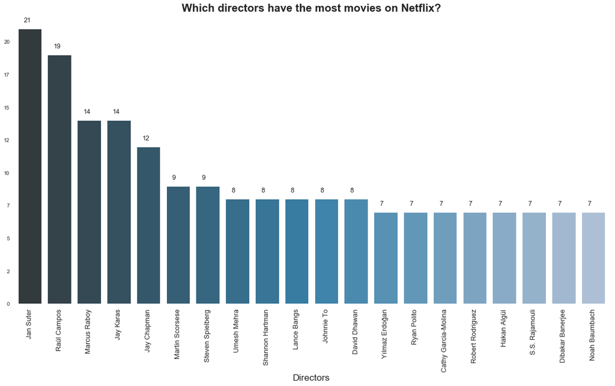

```python
plt.figure(figsize=(20,10))
sns.set(style="white")

ax = sns.countplot(x="director", data=movies_director_df, palette='PuBu_d', order = movies_director_df.director.value_counts().iloc[:20].index)

ax.grid(False)
ax.set_xticklabels(ax.get_xticklabels(),rotation = 90, fontsize = 13)
ax.set_yticklabels(ax.get_yticks(), size = 10)
sns.despine(bottom = True, left = True)
plt.title('Which directors have the most movies on Netflix?', fontsize = 20.5, fontweight = 'bold')
plt.xlabel('Directors', fontsize = 17.5)
plt.ylabel('')
plt.gca().yaxis.set_major_formatter(FuncFormatter(lambda x, _: int(x)))

for p in ax.patches:
    ax.annotate('{:}'.format(p.get_height()),(p.get_x()+0.2, p.get_height()+0.5), fontsize = 12.5)
```

# A look at the directors in the countries with highest amount of movies

```python
movies_director_df = pd.merge(movies_country_df, movies_director_df, on='show_id', how = 'inner')
movies_director_df = movies_director_df.groupby(['director','country']).size().reset_index(name='count')
```

```python
country_list = ['United States', 'India', 'United Kingdom', 'France', 'Canada', 'Spain' ]
movies_director_df = movies_director_df[movies_director_df['country'].isin(country_list)]
```

```python
movies_director_df = movies_director_df.groupby(['country']).apply(lambda x: x.sort_values(['count'],ascending = False)).reset_index(drop = True)
movies_director_df = movies_director_df.groupby(['country']).head(10)
```

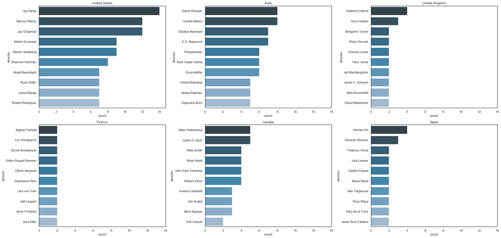

```python
f, axes = plt.subplots(2, 3, figsize=(25, 12), sharex=False)

ax1 = sns.barplot(x = 'count', y = 'director', data = movies_director_df[movies_director_df['country'] == 'United States'], palette="PuBu_d", ax=axes[0, 0]).set_title("United States")

ax2 = sns.barplot(x = 'count', y = 'director', data = movies_director_df[movies_director_df['country'] == 'India'], palette="PuBu_d", ax=axes[0, 1]).set_title("India")

ax3 = sns.barplot(x = 'count', y = 'director', data = movies_director_df[movies_director_df['country'] == 'United Kingdom'], palette="PuBu_d", ax=axes[0, 2]).set_title("United Kingdom")

ax4 = sns.barplot(x = 'count', y = 'director', data = movies_director_df[movies_director_df['country'] == 'France'], palette="PuBu_d", ax=axes[1, 0]).set_title("France")

ax5 = sns.barplot(x = 'count', y = 'director', data = movies_director_df[movies_director_df['country'] == 'Canada'], palette="PuBu_d", ax=axes[1, 1]).set_title("Canada")

ax6 = sns.barplot(x = 'count', y = 'director', data = movies_director_df[movies_director_df['country'] == 'Spain'], palette="PuBu_d", ax=axes[1, 2]).set_title("Spain")


plt.setp(axes, xticks=np.arange(0,16,2))
plt.tight_layout()
```

# Artists with most content on Netflix (Worldwide)

```python
movies_cast_df = movies_df[['show_id', 'cast']]
movies_cast_df = movies_cast_df.dropna()
```

```python
movies_cast_df['cast'] = movies_cast_df.cast.str.replace(", | ,", ",")
```

```python
movies_cast_df = pd.DataFrame(movies_cast_df.cast.str.split(',').tolist(), index=movies_cast_df.show_id).stack()
movies_cast_df = movies_cast_df.reset_index([0, 'show_id'])
movies_cast_df.columns = ['show_id', 'cast']
```

[figure not shown]

```python
plt.figure(figsize=(20,10))
sns.set(style="white")

ax = sns.countplot(x="cast", data=movies_cast_df, palette='PuBu_d', order = movies_cast_df.cast.value_counts().iloc[:20].index)

ax.grid(False)
ax.set_xticklabels(ax.get_xticklabels(),rotation = 90, fontsize = 13)
ax.set_yticklabels(ax.get_yticks(), size = 10)
sns.despine(bottom = True, left = True)
plt.title('Which artists have the most movies on Netflix?', fontsize = 20.5, fontweight = 'bold')
plt.xlabel('Actors', fontsize = 17.5)
plt.ylabel('')
plt.gca().yaxis.set_major_formatter(FuncFormatter(lambda x, _: int(x)))

for p in ax.patches:
    ax.annotate('{:}'.format(p.get_height()),(p.get_x()+0.2, p.get_height()+0.5), fontsize = 12.5)
```

# A look at the artists in the countries with highest amount of movies

```python
movies_cast_df = pd.merge(movies_country_df, movies_cast_df, on='show_id', how = 'inner')
movies_cast_df = movies_cast_df.groupby(['cast','country']).size().reset_index(name='count')
```

```python
country_list = ['United States', 'India', 'United Kingdom', 'France', 'Canada', 'Spain']
movies_cast_df = movies_cast_df[movies_cast_df['country'].isin(country_list)]
```

```python
movies_cast_df = movies_cast_df.groupby(['country']).apply(lambda x: x.sort_values(['count'],ascending = False)).reset_index(drop = True)
movies_cast_df = movies_cast_df.groupby(['country']).head(10)
```

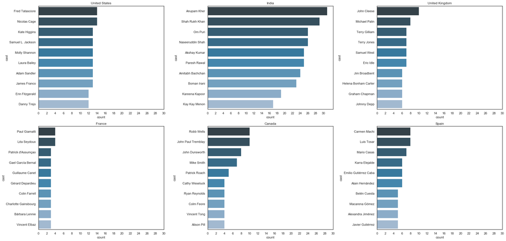

```python
f, ax = plt.subplots(2, 3, figsize=(25, 12), sharex=False)

ax1 = sns.barplot(x = 'count', y = 'cast', data = movies_cast_df[movies_cast_df['country'] == 'United States'], palette="PuBu_d", ax=ax[0, 0]).set_title("United States")

ax2 = sns.barplot(x = 'count', y = 'cast', data = movies_cast_df[movies_cast_df['country'] == 'India'], palette="PuBu_d", ax=ax[0, 1]).set_title("India")

ax3 = sns.barplot(x = 'count', y = 'cast', data = movies_cast_df[movies_cast_df['country'] == 'United Kingdom'], palette="PuBu_d", ax=ax[0, 2]).set_title("United Kingdom")

ax4 = sns.barplot(x = 'count', y = 'cast', data = movies_cast_df[movies_cast_df['country'] == 'France'], palette="PuBu_d", ax=ax[1, 0]).set_title("France")

ax5 = sns.barplot(x = 'count', y = 'cast', data = movies_cast_df[movies_cast_df['country'] == 'Canada'], palette="PuBu_d", ax=ax[1, 1]).set_title("Canada")

ax6 = sns.barplot(x = 'count', y = 'cast', data = movies_cast_df[movies_cast_df['country'] == 'Spain'], palette="PuBu_d", ax=ax[1, 2]).set_title("Spain")


plt.setp(ax, xticks=np.arange(0,32,2))
plt.tight_layout()
```

# How the movies are divided based on their audience ratings

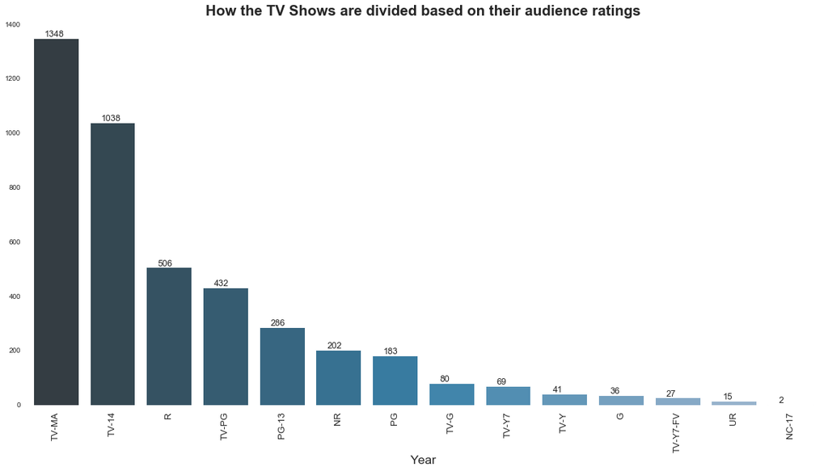

```python
plt.figure(figsize=(20,10))
sns.set(style="white")

ax = sns.countplot(x="rating", data=movies_df, palette='PuBu_d', order = movies_df.rating.value_counts().index)

ax.grid(False)
ax.set_xticklabels(ax.get_xticklabels(),rotation = 90, fontsize = 13)
ax.set_yticklabels(ax.get_yticks(), size = 10)
sns.despine(bottom = True, left = True)
plt.title('How the TV Shows are divided based on their audience ratings', fontsize = 20.5, fontweight = 'bold')
plt.xlabel('Year', fontsize = 17.5)
plt.ylabel('')
plt.gca().yaxis.set_major_formatter(FuncFormatter(lambda x, _: int(x)))

for p in ax.patches:
        ax.annotate('{:}'.format(p.get_height()),(p.get_x()+0.2, p.get_height()+5), fontsize = 12.5)
```

# Working with the TV Shows subset

```python
tv_df.head(10)
```

|  | show_id | type | title | director | cast | country | date_added | release_year | rating | duration | listed_in | description |
| --- | --- | --- | --- | --- | --- | --- | --- | --- | --- | --- | --- | --- |
| 2 | 70234439 | TV Show | Transformers Prime | NaN | Peter Cullen, Sumalee Montano, Frank Welker, J... | United States | September 8, 2018 | 2013 | TV-Y7-FV | 1 Season | Kids' TV | With the help of three human allies, the Autob... |
| 3 | 80058654 | TV Show | Transformers: Robots in Disguise | NaN | Will Friedle, Darren Criss, Constance Zimmer, ... | United States | September 8, 2018 | 2016 | TV-Y7 | 1 Season | Kids' TV | When a prison ship crash unleashes hundreds of... |
| 5 | 80163890 | TV Show | Apaches | NaN | Alberto Ammann, Eloy Azorín, Verónica Echegui,... | Spain | September 8, 2017 | 2016 | TV-MA | 1 Season | Crime TV Shows, International TV Shows, Spanis... | A young journalist is forced into a life of cr... |
| 8 | 80117902 | TV Show | Fire Chasers | NaN | NaN | United States | September 8, 2017 | 2017 | TV-MA | 1 Season | Docuseries, Science & Nature TV | As California's 2016 fire season rages, brave ... |
| 26 | 80244601 | TV Show | Castle of Stars | NaN | Chaiyapol Pupart, Jintanutda Lummakanon, Worra... | NaN | September 7, 2018 | 2015 | TV-14 | 1 Season | International TV Shows, Romantic TV Shows, TV ... | As four couples with different lifestyles go t... |
| 28 | 80190843 | TV Show | First and Last | NaN | NaN | NaN | September 7, 2018 | 2018 | TV-MA | 1 Season | Docuseries | Take an intimate look at the emotionally charg... |
| 34 | 80221550 | TV Show | Archibald's Next Big Thing | NaN | Tony Hale, Rosamund Pike, Jordan Fisher, Chels... | NaN | September 6, 2019 | 2019 | TV-Y7 | 1 Season | Kids' TV, TV Comedies | Happy-go-lucky chicken Archibald may not remem... |
| 39 | 80178151 | TV Show | The Spy | NaN | Sacha Baron Cohen, Noah Emmerich, Hadar Ratzon... | France | September 6, 2019 | 2019 | TV-MA | 1 Season | International TV Shows, TV Dramas, TV Thrillers | In the 1960s, Israeli clerk-turned-secret agen... |
| 54 | 80113482 | TV Show | No Tomorrow | NaN | Joshua Sasse, Tori Anderson, Jonathan Langdon,... | United States | September 5, 2017 | 2016 | TV-14 | 1 Season | Romantic TV Shows, TV Comedies, TV Dramas | Her straitjacketed life turned topsy-turvy by ... |
| 61 | 80113641 | TV Show | Frequency | NaN | Peyton List, Riley Smith, Mekhi Phifer, Devin ... | United States | September 4, 2017 | 2016 | TV-14 | 1 Season | Crime TV Shows, TV Dramas, TV Mysteries | A detective seizes a precious opportunity to c... |

```python
tv_df.shape
```

```
(1969, 12)
```

Checking for the NA values

```python
tv_df.isna().sum()
```

```
show_id            0
type               0
title              0
director        1841
cast             210
country          281
date_added        10
release_year       0
rating             0
duration           0
listed_in          0
description        0
dtype: int64
```

We will fill the NA values in the 'country' column with 'Undefined'.

We will also fill the empty instances in 'date_added' column with the year as 2020.

```python
tv_df['date_added'] = tv_df['date_added'].fillna('January 1, 2020')
```

```python
tv_df['country'] = tv_df['country'].fillna('Undefined')
```

Adding two more columns to the tv show subset: one containing the month the content was added and other containing the year it was added in

```python
tv_df['month_added'] = pd.to_datetime(tv_df['date_added']).dt.month_name()
tv_df['year_added'] = pd.to_datetime(tv_df['date_added']).dt.year
```

In order to visualize the country and genres of the tv shows, we first need to clean the columns and bring them in an uniform format.

By taking a closer look at the dataset we see that the comma spacing in some instances is different than others.

```python
tv_df['listed_in'] = tv_df.listed_in.str.replace(", | ,", ",")
tv_df['country'] = tv_df.country.str.replace(", | ,", ",")
```

Now once we have the column in an uniform format, we split the column and create a new dataframe containg the show_id and the country names where the tv show was released

# Which are the countries where most number of TV Shows are available?

```python
tv_country_df = pd.DataFrame(tv_df.country.str.split(',').tolist(), index=tv_df.show_id).stack()
tv_country_df = tv_country_df.reset_index([0, 'show_id'])
tv_country_df.columns = ['show_id', 'country']
```

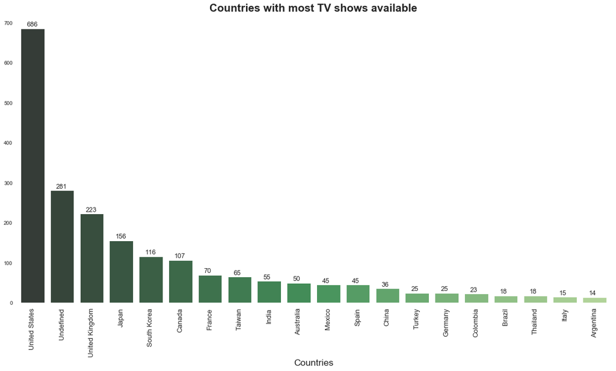

```python
plt.figure(figsize=(20,10))
sns.set(style="white")

ax = sns.countplot(x="country", data=tv_country_df, palette='YlGn_d', order = tv_country_df.country.value_counts().iloc[:20].index)

ax.grid(False)
ax.set_xticklabels(ax.get_xticklabels(),rotation = 90, fontsize = 13)
ax.set_yticklabels(ax.get_yticks(), size = 10)
sns.despine(bottom = True, left = True)
plt.title('Countries with most TV shows available', fontsize = 20.5, fontweight = 'bold')
plt.xlabel('Countries', fontsize = 17.5)
plt.ylabel('')
plt.gca().yaxis.set_major_formatter(FuncFormatter(lambda x, _: int(x)))

for p in ax.patches:
        ax.annotate('{:}'.format(p.get_height()),(p.get_x()+0.2, p.get_height()+5), fontsize = 12.5)
```

We again observe that United States has the most number of TV Shows available. A concern we have here is that there are many instances where the countries in which the content is available are missing and that category is second highest in terms of its occurrence.

# Which TV Show genres are the most frequent on Netflix?

```python
tv_genre_df = pd.DataFrame(tv_df.listed_in.str.split(',').tolist(), index=tv_df.show_id).stack()
tv_genre_df = tv_genre_df.reset_index([0, 'show_id'])
tv_genre_df.columns = ['show_id', 'genre']
```

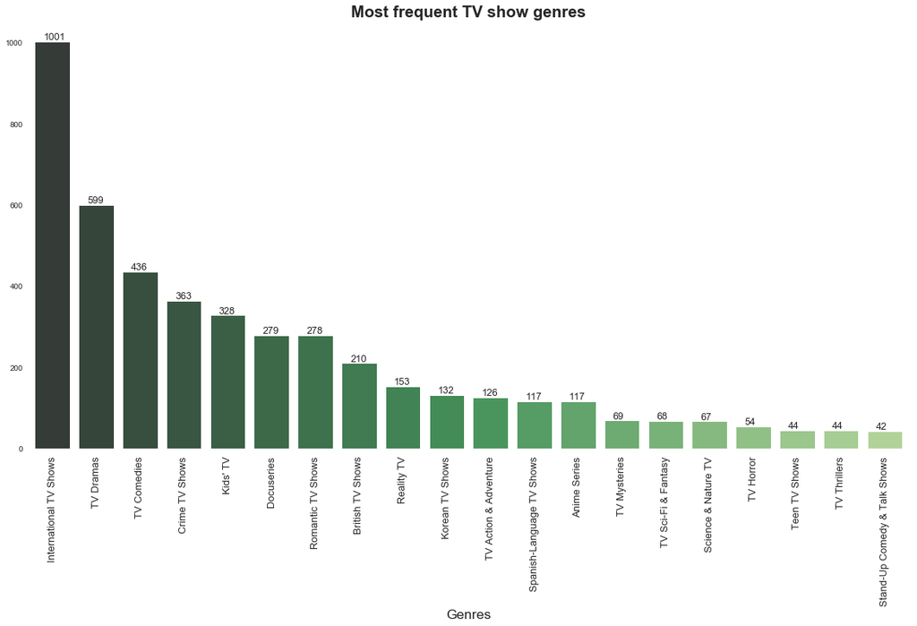

```python
plt.figure(figsize=(20,10))
sns.set(style="white")

ax = sns.countplot(x="genre", data=tv_genre_df, palette="YlGn_d", order = tv_genre_df.genre.value_counts().iloc[:20].index)

ax.grid(False)
ax.set_xticklabels(ax.get_xticklabels(),rotation = 90, fontsize = 13)
ax.set_yticklabels(ax.get_yticks(), size = 10)
sns.despine(bottom = True, left = True)
plt.title('Most frequent TV show genres', fontsize = 20.5, fontweight = 'bold')
plt.xlabel('Genres', fontsize = 17.5)
plt.ylabel('')
plt.gca().yaxis.set_major_formatter(FuncFormatter(lambda x, _: int(x)))

for p in ax.patches:
        ax.annotate('{:}'.format(p.get_height()),(p.get_x()+0.2, p.get_height()+5), fontsize = 12.5)
```

# Which year saw the most number of TV Shows getting added on Netflix?

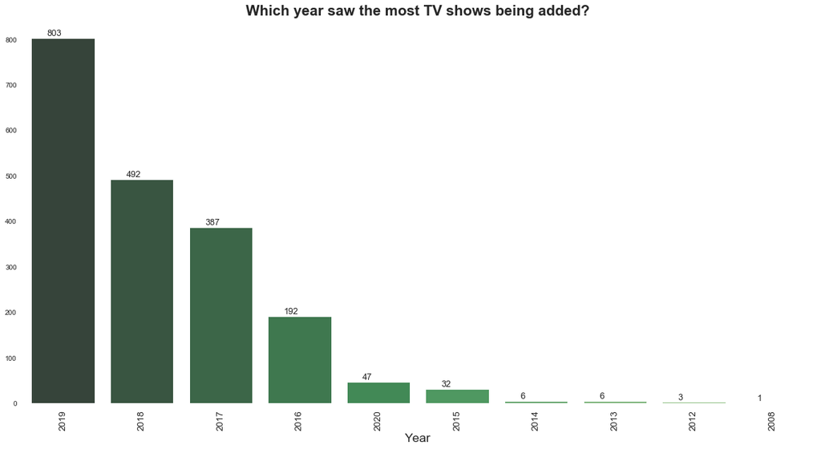

```python
plt.figure(figsize=(20,10))
sns.set(style="white")

ax = sns.countplot(x="year_added", data=tv_df, palette='YlGn_d', order = tv_df.year_added.value_counts().index)

ax.grid(False)
ax.set_xticklabels(ax.get_xticklabels(),rotation = 90, fontsize = 13)
ax.set_yticklabels(ax.get_yticks(), size = 10)
sns.despine(bottom = True, left = True)
plt.title('Which year saw the most TV shows being added?', fontsize = 20.5, fontweight = 'bold')
plt.xlabel('Year', fontsize = 17.5)
plt.ylabel('')
plt.gca().yaxis.set_major_formatter(FuncFormatter(lambda x, _: int(x)))

for p in ax.patches:
        ax.annotate('{:}'.format(p.get_height()),(p.get_x()+0.2, p.get_height()+5), fontsize = 12.5)
```

# Which months saw the most number of TV Shows getting added on Netflix? (All years inclusive)

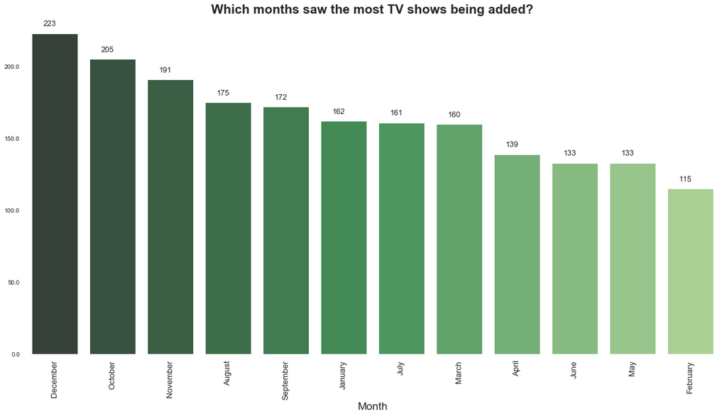

```python
plt.figure(figsize=(20,10))
sns.set(style="white")

ax = sns.countplot(x="month_added", data=tv_df, palette='YlGn_d', order = tv_df.month_added.value_counts().index)

ax.grid(False)
ax.set_xticklabels(ax.get_xticklabels(),rotation = 90, fontsize = 13)
ax.set_yticklabels(ax.get_yticks(), size = 10)
sns.despine(bottom = True, left = True)
plt.title('Which months saw the most TV shows being added?', fontsize = 20.5, fontweight = 'bold')
plt.xlabel('Month', fontsize = 17.5)
plt.ylabel('')

for p in ax.patches:
        ax.annotate('{:}'.format(p.get_height()),(p.get_x()+0.2, p.get_height()+5), fontsize = 12.5)
```

# Heatmap to drill down into the month-year relationship

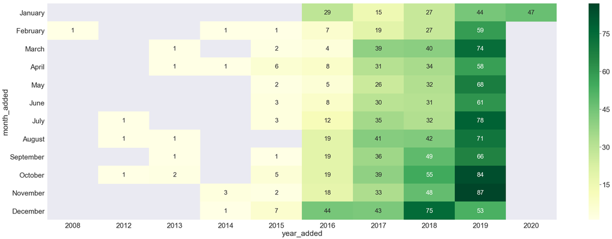

```python
plt.figure(figsize=(20,10))

tv_heatmap_df = tv_df.groupby(['year_added', 'month_added']).size().reset_index(name='count')

month_ordered = [ 'January', 'February', 'March', 'April', 'May', 'June', 'July', 'August','September','October','November','December']

tv_heatmap_df['month_added'] = tv_heatmap_df['month_added'].astype(pd.api.types.CategoricalDtype(month_ordered))

plt.figure(figsize=(40,14))
sns.set(font_scale=2.25)

ax = pd.pivot_table(tv_heatmap_df, values= 'count', index=['month_added'], columns='year_added')
sns.heatmap(ax, cmap="YlGn", annot = True, annot_kws = {'size':22})
```

# A genrewise look at how the TV Shows got added over the years

```python
tv_genrewise_df = tv_df[['show_id', 'year_added']]
tv_genrewise_df = pd.merge(tv_genre_df, tv_genrewise_df, on='show_id')
```

```python
tv_genrewise_df = tv_genrewise_df.groupby(['year_added', 'genre']).size().reset_index(name='count')
```

```python
genre_list = ['International TV Shows','TV Dramas','TV Comedies','Crime TV Shows','Docuseries', 'Romantic TV Shows','British TV Shows',"Kids' TV", 'Reality TV', 'Korean TV Shows' ]
tv_genrewise_df = tv_genrewise_df[tv_genrewise_df['genre'].isin(genre_list)]
```

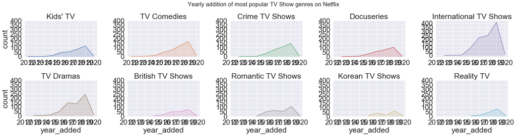

```python
g = sns.FacetGrid(tv_genrewise_df, col= 'genre', hue='genre', col_wrap=5, height = 3.5, aspect = 1.5, sharex = False, sharey = False)
g = g.map(plt.plot, 'year_added', 'count')
g = g.map(plt.fill_between, 'year_added', 'count', alpha=0.2).set_titles("{col_name} country")
g = g.set_titles("{col_name}")
g = g.set(xticks=np.arange(2012, 2021, 1), yticks = np.arange(0,450,50))
plt.subplots_adjust(top=0.85)
g.fig.suptitle('Yearly addition of most popular TV Show genres on Netflix', fontsize = 20.5)
```

# Artists with the most TV content on Netflix (Worldwide)

```python
tv_cast_df = tv_df[['show_id', 'cast']]
tv_cast_df = tv_cast_df.dropna()
```

```python
tv_cast_df['cast'] = tv_cast_df.cast.str.replace(", | ,", ",")
```

```python
tv_cast_df = pd.DataFrame(tv_cast_df.cast.str.split(',').tolist(), index=tv_cast_df.show_id).stack()
tv_cast_df = tv_cast_df.reset_index([0, 'show_id'])
tv_cast_df.columns = ['show_id', 'cast']
```

[figure not shown]

```python
plt.figure(figsize=(20,10))
sns.set(style="white")

ax = sns.countplot(x="cast", data=tv_cast_df, palette='YlGn_d', order = tv_cast_df.cast.value_counts().iloc[:20].index)

ax.grid(False)
ax.set_xticklabels(ax.get_xticklabels(),rotation = 90, fontsize = 13)
ax.set_yticklabels(ax.get_yticks(), size = 10)
sns.despine(bottom = True, left = True)
plt.title('Which artists have the most TV Shows on Netflix??', fontsize = 20.5, fontweight = 'bold')
plt.xlabel('Cast', fontsize = 17.5)
plt.ylabel('')
plt.gca().yaxis.set_major_formatter(FuncFormatter(lambda x, _: int(x)))

for p in ax.patches:
    ax.annotate('{:}'.format(p.get_height()),(p.get_x()+0.2, p.get_height()+0.5), fontsize = 12.5)
```

# A look at the artists in the countries with highest amount of TV Shows

```python
tv_cast_df = pd.merge(tv_country_df, tv_cast_df, on='show_id', how = 'inner')
tv_cast_df = tv_cast_df.groupby(['cast','country']).size().reset_index(name='count')
```

```python
country_list = ['United States', 'United Kingdom', 'Japan', 'South Korea', 'Canada', 'Taiwan']
tv_cast_df = tv_cast_df[tv_cast_df['country'].isin(country_list)]
```

```python
tv_cast_df = tv_cast_df.groupby(['country']).apply(lambda x: x.sort_values(['count'],ascending = False)).reset_index(drop = True)
tv_cast_df = tv_cast_df.groupby(['country']).head(10)
```

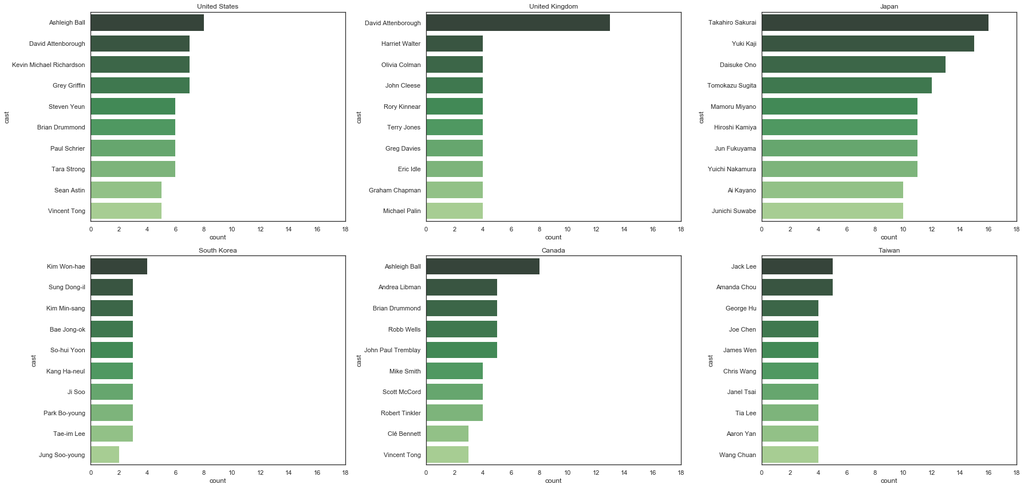

```python
f, axes = plt.subplots(2, 3, figsize=(25, 12), sharex=False)

ax1 = sns.barplot(x = 'count', y = 'cast', data = tv_cast_df[tv_cast_df['country'] == 'United States'], palette="YlGn_d", ax=axes[0, 0]).set_title("United States")

ax2 = sns.barplot(x = 'count', y = 'cast', data = tv_cast_df[tv_cast_df['country'] == 'United Kingdom'], palette="YlGn_d", ax=axes[0, 1]).set_title("United Kingdom")

ax3 = sns.barplot(x = 'count', y = 'cast', data = tv_cast_df[tv_cast_df['country'] == 'Japan'], palette="YlGn_d", ax=axes[0, 2]).set_title("Japan")

ax4 = sns.barplot(x = 'count', y = 'cast', data = tv_cast_df[tv_cast_df['country'] == 'South Korea'], palette="YlGn_d", ax=axes[1, 0]).set_title("South Korea")

ax5 = sns.barplot(x = 'count', y = 'cast', data = tv_cast_df[tv_cast_df['country'] == 'Canada'], palette="YlGn_d", ax=axes[1, 1]).set_title("Canada")

ax6 = sns.barplot(x = 'count', y = 'cast', data = tv_cast_df[tv_cast_df['country'] == 'Taiwan'], palette="YlGn_d", ax=axes[1, 2]).set_title("Taiwan")




plt.setp(axes, xticks=np.arange(0,20,2))
plt.tight_layout()
```

# How the TV Shows are divided based on their audience ratings

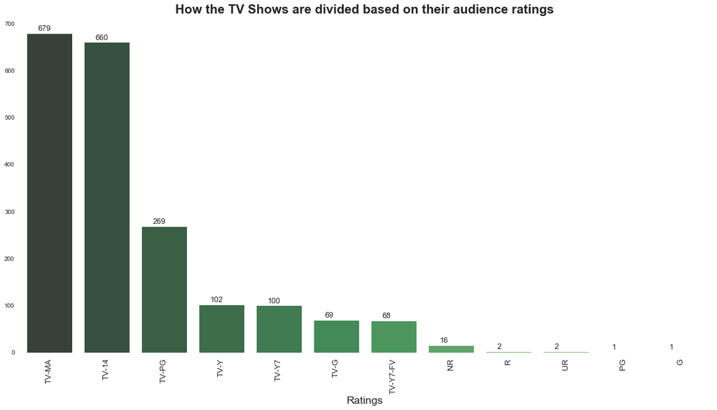

```python
plt.figure(figsize=(20,10))
sns.set(style="white")

ax = sns.countplot(x="rating", data=tv_df, palette='YlGn_d', order = tv_df.rating.value_counts().index)

ax.grid(False)
ax.set_xticklabels(ax.get_xticklabels(),rotation = 90, fontsize = 13)
ax.set_yticklabels(ax.get_yticks(), size = 10)
sns.despine(bottom = True, left = True)
plt.title('How the TV Shows are divided based on their audience ratings', fontsize = 20.5, fontweight = 'bold')
plt.xlabel('Ratings', fontsize = 17.5)
plt.ylabel('')
plt.gca().yaxis.set_major_formatter(FuncFormatter(lambda x, _: int(x)))

for p in ax.patches:
        ax.annotate('{:}'.format(p.get_height()),(p.get_x()+0.2, p.get_height()+5), fontsize = 12.5)
```